# Data structures and visualization

Louis Luangkesorn

January 2019

# Features of R

- an effective data handling and storage facility,
- a suite of operators for calculations on arrays, in particular matrices,
- a large, coherent, integrated collection of intermediate tools for data analysis,
- graphical facilities for data analysis and display either directly at the computer or on hardcopy, and
- a well developed, simple and effective programming language (called ‘S’) which includes conditionals, loops, user defined recursive functions and input and output facilities.

# Working with R

- R is an computational environment and a programming language.
- The benefit of a programming language is that analysis is reproducable, just change the data set.
- The benefit of a computational environment is that you can inspect the options you have available while you are performing the analysis.

# Getting help

- R-Studio help is typically in the lower left.
- Manuals (An Introduction to R)
- Installed packages
- Search capability
- Type `help(function)` in the Console

```r
help(solve)
```

```
## starting httpd help server ... done
```

# Data

type: section

# Working with data

- R generally uses dynamic typing, you do not declare your variables.
- A variable can have text, integers, or numbers.
- Typing in a variable name gives the contents of the variable (also available in the `Environment` window in the upper right of R Studio)
- Typing in a function name with no parenthesis shows the source code of the function.

# Vectors

- The base unit of data that can be analyzed is the *vector*
- Operations on a vector are performed on all members
- Many mathematical functions also work on vectors.

```r
x <- c(10.4, 5.6, 3.1, 6.4, 21.7)
print(1/x)
```

```
## [1] 0.09615385 0.17857143 0.32258065 0.15625000 0.04608295
```

```r
print(c(mean(x), sd(x)))
```

```
## [1] 9.44000 7.33846
```

# Logical vectors

- If you use an `if -> else` statement on a vector, you get a vector of `TRUE/FALSE` values

```r
x > 5
```

```
## [1]  TRUE  TRUE FALSE  TRUE  TRUE
```

# Representing data

- We often represent data as rows and columns.
- Usually, a row is a record, each column contains information about that record.
- We could put them in a matrix, but sometimes the columns are not numbers.
- A `data.frame` can recognize that each column is of a different type and will treat it correctly.

# Data frames

- *Data frames* are the key data structure you will use.
- Composed of vectors, factors, matrices, lists, or other data frames.
- Think of them as a list of records, where each record contains many different types of information.
- Create a data frame by using `data.frame` with a list of the columns and the variables that contain the data for each column.

```
> accountants <- data.frame(home=statef, loot=incomes, shot=incomef)
```

# Plotting with ggplot2

type: section

# Packages

- `Packages` are libraries that contain functionality for R
- These libraries include the machine learning and text processing methods that we will use.
- ‘ggplot’ is a library that implements the *Grammer of Graphics*, plots are built from components.
- It is very flexible.

```r
library(ggplot2)
```

# Random numbers

- We use random numbers to sample from data (smaller datasets are often more manageable) or to create data to test methods on or for simulation.

```r
set.seed(1234)
runif(n=4, 0, 1)
```

```
## [1] 0.1137034 0.6222994 0.6092747 0.6233794
```

# Some examples

- Take some samples from the `diamonds` dataset that comes with `ggplot2`
- Note the `,` which indicates that you are getting all of the columns.

```r
library(ggplot2)
set.seed(1410)
dsmall = diamonds[sample(nrow(diamonds),200),]
```

# Introduction to ggplot

- *ggplot* treats plots as a collection of layers.
- The layers can be modified independently.
- Data, appearance, plot type, and formatting are treated separately.
- Allows for quick replacement of data using same parameters or exploring different representations of the same data.

# Introduction to ggplot

- Compents of a ggplot
- data
- aesthetic mapping between data variables and visual properties
- a layer which describes how to render each observation

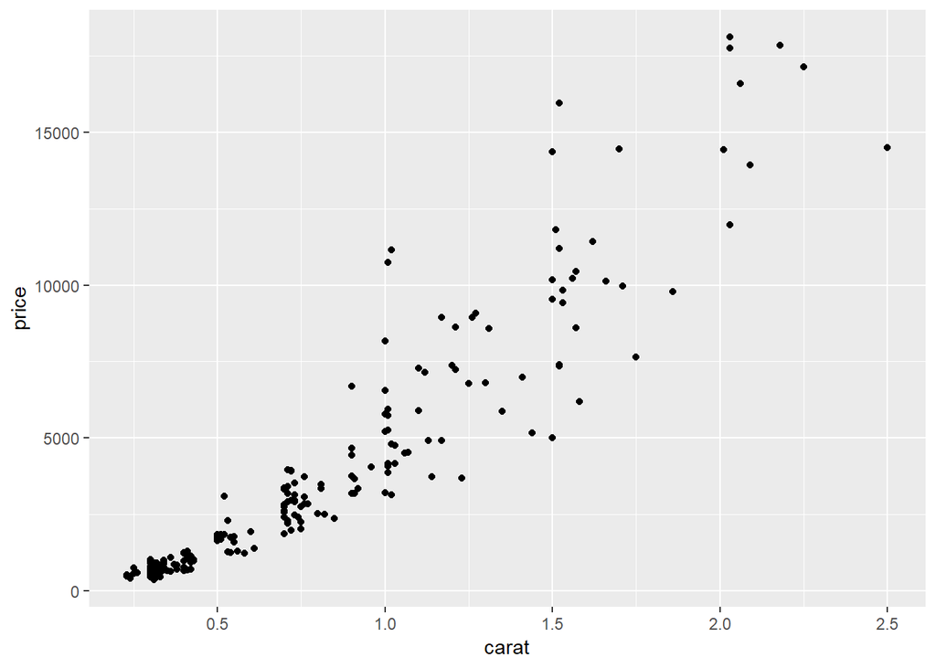

```r
ggplot(dsmall, aes(x=carat, y=price)) + geom_point()
```

# plotting transforms

- You can transform the data using calculations

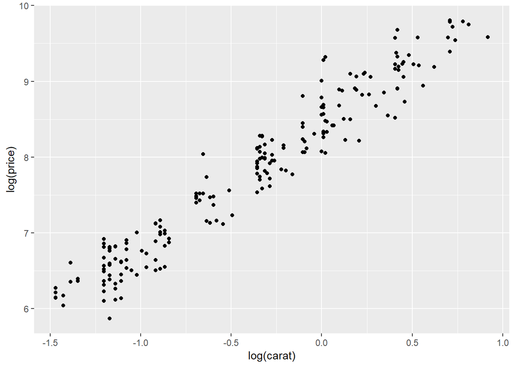

```r
ggplot(dsmall, aes(x=log(carat), y=log(price))) + geom_point()
```

# Aesthetics - appearance

- Change the appearance of data elements using aesthetics.
- Color, shape, size, transparancy (alpha), etc.
- Each aesthetic displays an additional aspect of the data.

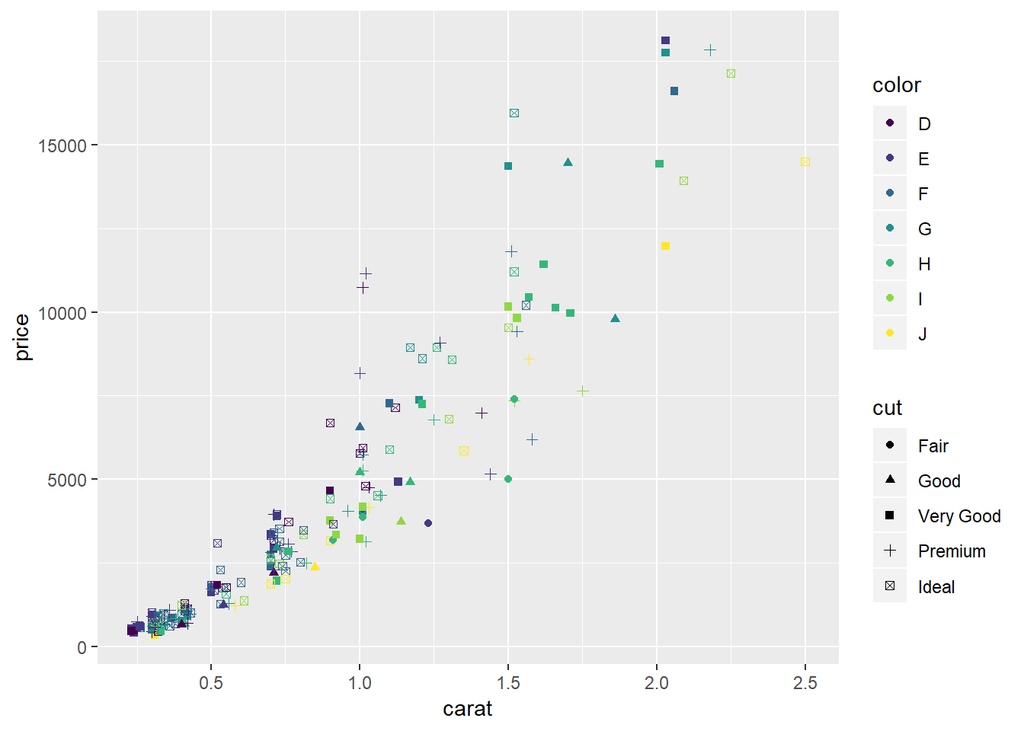

```r
ggplot(dsmall, aes(x=carat, y=price, shape=cut, colour=color)) + geom_point()
```

# Five named graphs

- The type of plot is set using `geom`
- `geom_point()` - Scatterplots,
- `geom_path()` and `geom_line()` connect points.
- `geom_histogram()`
- `geom_boxplot()`
- `geom_bar()`
- Alternatively, the `stat` family of functions

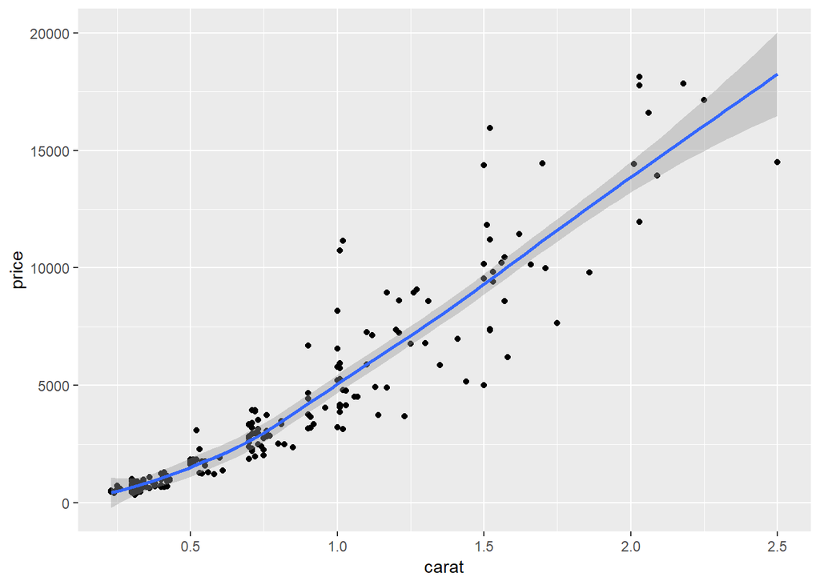

```r
ggplot(dsmall, aes(x=carat, y=price)) + geom_point() +geom_smooth()
```

# Boxplots

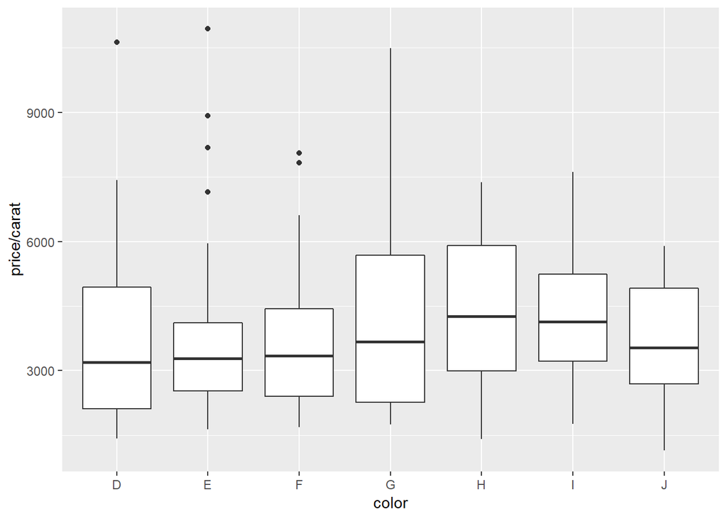

```r
ggplot(dsmall, aes(x=color, y=price/carat)) + geom_boxplot()
```

# Jitter

- `jitter` shifts data points that would otherwise be on top of each other.

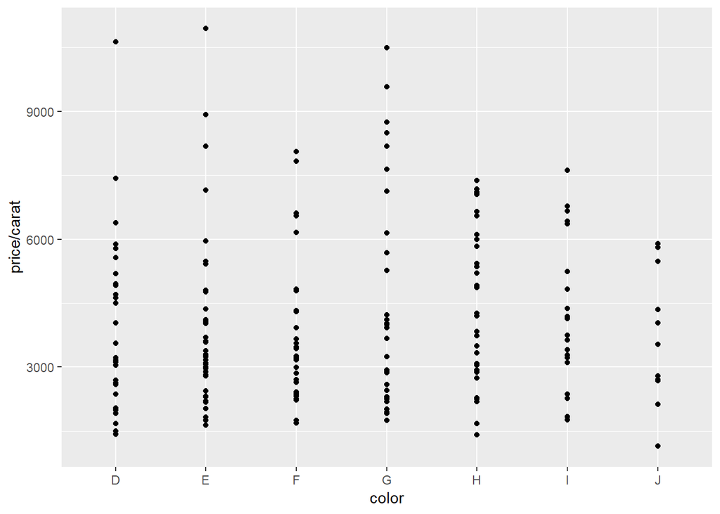

```r
ggplot(dsmall, aes(x=color, y=price/carat)) + geom_point()
```

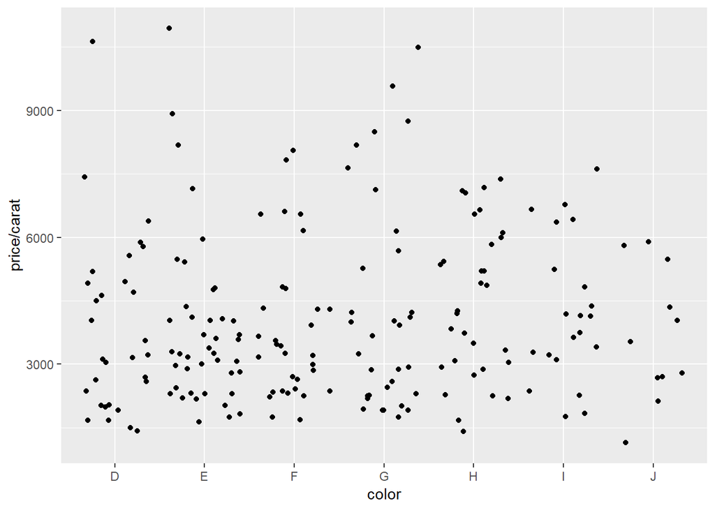

```r
ggplot(dsmall, aes(x=color, y=price/carat)) + geom_jitter()
```

# alpha

- `alpha` adjusts the transparancy, so it is more apparent that multiple data points overlap.

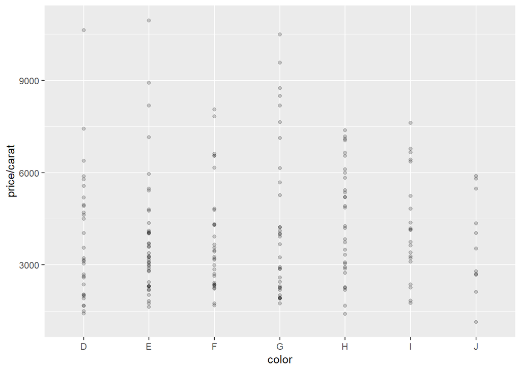

```r
ggplot(dsmall, aes(x=color, y=price/carat)) + geom_point(alpha = 1/5)
```

# Histograms

- Histograms and density show distributions.

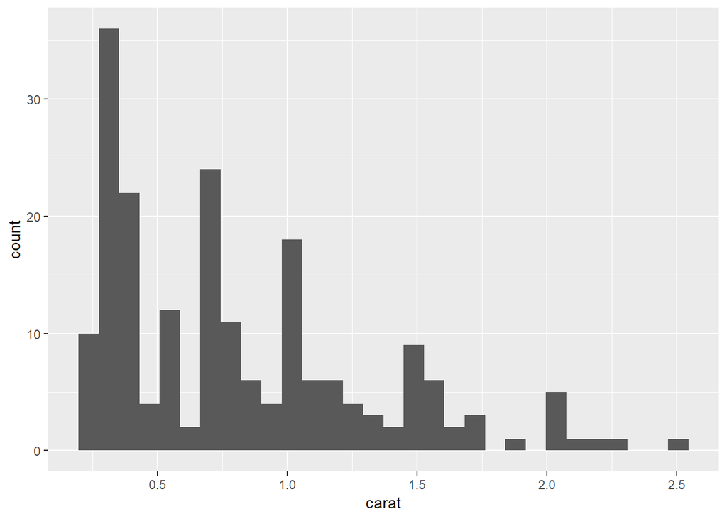

```r
ggplot(dsmall, aes(x=carat)) + geom_histogram()
```

# Density plot

- Histograms and density show distributions.

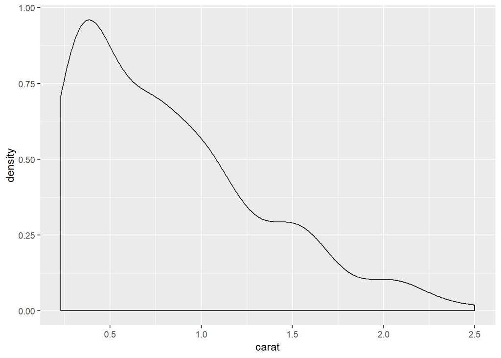

```r
ggplot(dsmall, aes(x=carat)) + geom_density()
```

# Plots and aesthetics

- Aesthetics can be used to create subplots

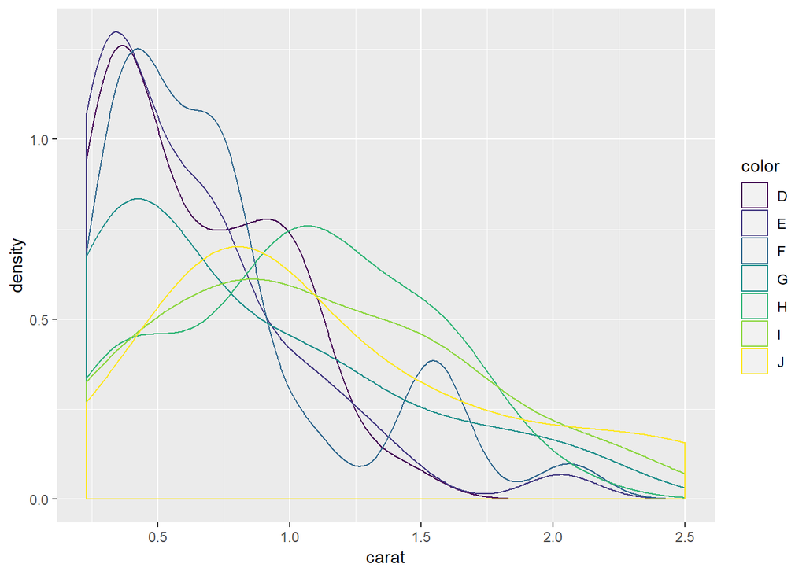

```r
ggplot(dsmall, aes(x=carat, colour=color)) + geom_density()
```

# Barcharts and aesthetics

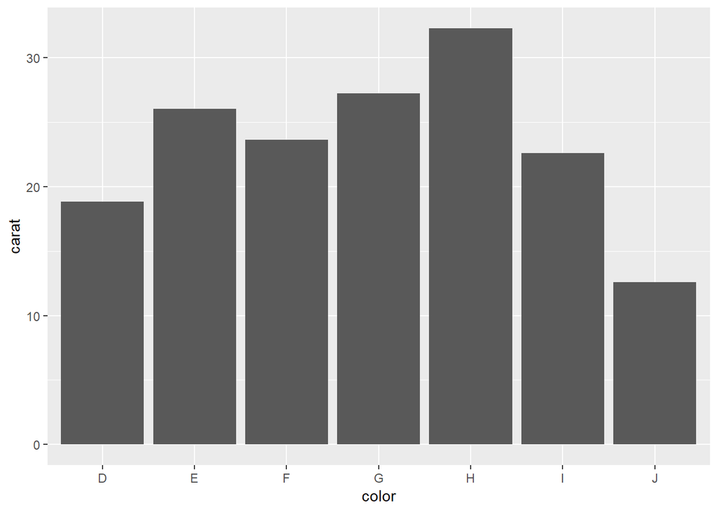

```r
ggplot(dsmall, aes(x=color, weight=carat)) + geom_bar()+ scale_y_continuous("carat")
```

# Time series

- Look at time series with a new dataset

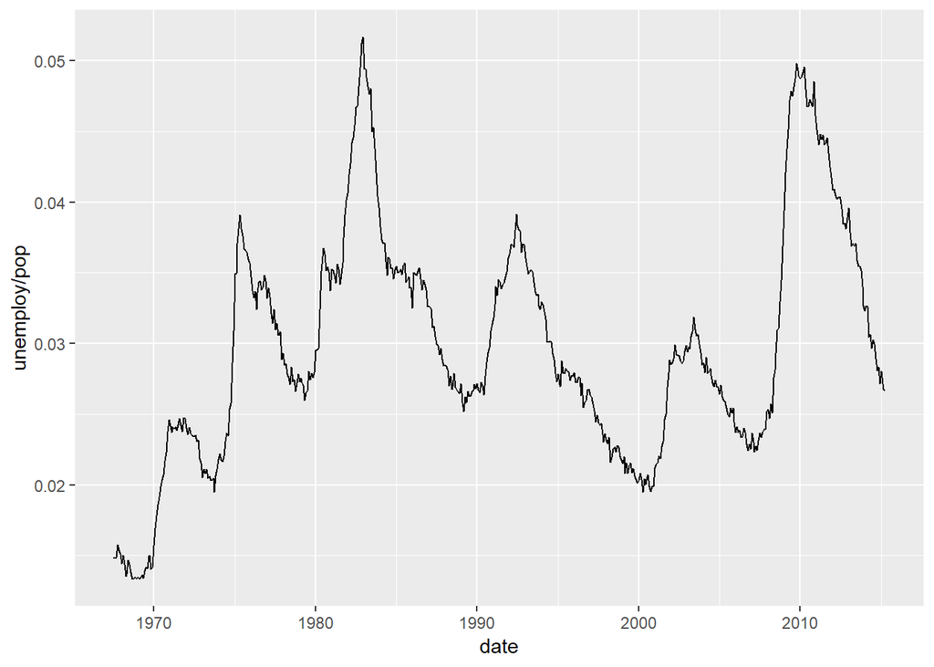

```r
data(economics)
ggplot(economics, aes(date, unemploy/pop)) + geom_line()
```

# Time series path plot

- We can put multiple time series on the same plot.

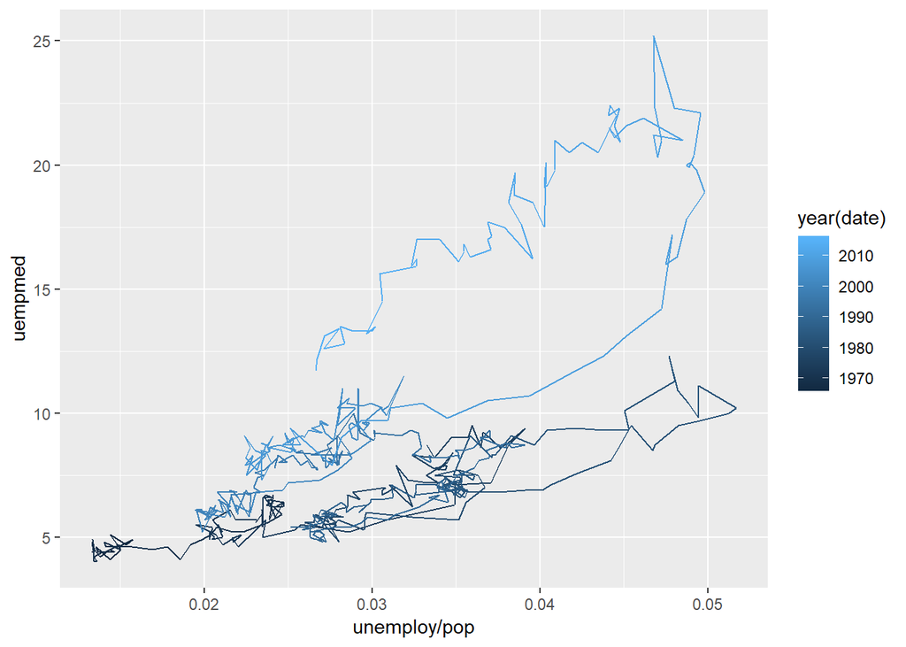

```r
year <- function(x) as.POSIXlt(x)$year + 1900
ggplot(economics, aes(unemploy/pop, uempmed, colour=year(date))) + geom_path()+ scale_size_area()
```

# Faceting

- `facets` creates a series of side by side plots where categories of data each get their own plot

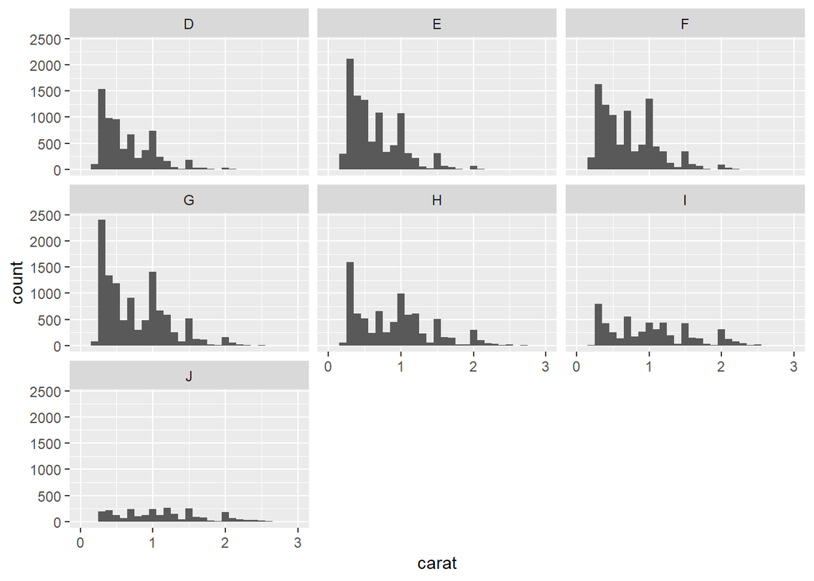

```r
data(diamonds)
ggplot(diamonds, aes(carat)) + geom_histogram(binwidth = 0.1) + facet_wrap(~color) + xlim(c(0,3))
```

# ggplot2 summary

A plot is composed of: - Data - aesthetic - Indicates the data - geom - Indicates the type of plot - facets - Indicates multiple plots

More can be found in *ggplot2: Elegant graphics for data analysis*